# IODS course project

# 3. Logistic regression

## 3.1 Reading in the data (step 2 of Analysis assignment)

First I read the wrangled data from my project folder:

```r
alko <- read.csv2("~/GitHub/IODS-project/data/alcohol.csv", header=TRUE)
dim(alko)
```

```
## [1] 382  35
```

```r
colnames(alko)
```

```
##  [1] "school"     "sex"        "age"        "address"    "famsize"
##  [6] "Pstatus"    "Medu"       "Fedu"       "Mjob"       "Fjob"
## [11] "reason"     "nursery"    "internet"   "guardian"   "traveltime"
## [16] "studytime"  "failures"   "schoolsup"  "famsup"     "paid"
## [21] "activities" "higher"     "romantic"   "famrel"     "freetime"
## [26] "goout"      "Dalc"       "Walc"       "health"     "absences"
## [31] "G1"         "G2"         "G3"         "alc_use"    "high_use"
```

Data concerns student achievement in secondary education of two Portuguese schools. The data attributes include student grades, demographic, social and school related features) and it was collected by using school reports and questionnaires. [More about the data:](https://archive.ics.uci.edu/ml/datasets/Student+Performance)

## 3.2 Choosing variables (step 3 of Analysis)

I chose the following four variables to indicate (not implying causation) a possible high level of alcohol consumption. For obvious reasons, I didn’t consider the variables that were used to calculate the **high_use** variable.

1. failures - number of failed classes. High level of consumption can affect school work negatively.
2. famrel - quality of family relationships (numeric: from 1 - very bad to 5 - excellent). High alcohol consumption might cause friction in family.
3. health - current health status (numeric: from 1 - very bad to 5 - very good). Heavy consumption can cause problems with health.
4. absences - number of school absences. Absenteeism might be caused by hangovers or staying up late in bars/clubs.

## 3.3 Exploring the variables (step 4)

### 3.3.1 Failed classes

```r
table(alko$failures,alko$high_use)
```

```
##
##     FALSE TRUE
##   0   244   90
##   1    12   12
##   2    10    9
##   3     2    3
```

The proportion of the heavy drinkers rises when number of failures rises, so there might be something there.

### 3.3.2 Family relations

```r
table(alko$famrel,alko$high_use)
```

```
##
##     FALSE TRUE
##   1     6    2
##   2    10    9
##   3    39   25
##   4   135   54
##   5    78   24
```

### 3.3.3 Health

```r
table(alko$health,alko$high_use)
```

```
##
##     FALSE TRUE
##   1    35   11
##   2    28   16
##   3    62   19
##   4    49   18
##   5    94   50
```

### 3.3.4 Absences

```r
table(alko$absences,alko$high_use)
```

```
##
##      FALSE TRUE
##   0     52   13
##   1     38   13
##   2     42   16
##   3     33    8
##   4     24   12
##   5     16    6
##   6     16    5
##   7      9    3
##   8     14    6
##   9      6    6
##   10     5    2
##   11     2    4
##   12     4    4
##   13     1    1
##   14     1    6
##   16     0    1
##   17     0    1
##   18     1    1
##   19     0    1
##   20     2    0
##   21     1    1
##   26     0    1
##   27     0    1
##   29     0    1
##   44     0    1
##   45     1    0
```

Some people have missed school quiten often…

## 3.4 Building the model (step 5)

We build a logistic regression model with our chosen variables:

```r
malli <- glm(high_use ~ failures + famrel + health + absences, data = alko, family = "binomial")
summary(malli)
```

```
##
## Call:
## glm(formula = high_use ~ failures + famrel + health + absences,
##     family = "binomial", data = alko)
##
## Deviance Residuals:
##     Min       1Q   Median       3Q      Max
## -2.2785  -0.7924  -0.6875   1.1549   1.9065
##
## Coefficients:
##             Estimate Std. Error z value Pr(>|z|)
## (Intercept) -0.76875    0.57570  -1.335 0.181766
## failures     0.45530    0.18396   2.475 0.013325 *
## famrel      -0.24444    0.12643  -1.933 0.053185 .
## health       0.09959    0.08665   1.149 0.250413
## absences     0.08371    0.02247   3.725 0.000195 ***
## ---
## Signif. codes:  0 '***' 0.001 '**' 0.01 '*' 0.05 '.' 0.1 ' ' 1
##
## (Dispersion parameter for binomial family taken to be 1)
##
##     Null deviance: 465.68  on 381  degrees of freedom
## Residual deviance: 435.51  on 377  degrees of freedom
## AIC: 445.51
##
## Number of Fisher Scoring iterations: 4
```

Only **failures** and **absences** seem to have statistically significant effect. Recalculating the model:

```r
malli <- glm(high_use ~ failures + absences, data = alko, family = "binomial")
summary(malli)
```

```
##
## Call:
## glm(formula = high_use ~ failures + absences, family = "binomial",
##     data = alko)
##
## Deviance Residuals:
##     Min       1Q   Median       3Q      Max
## -2.2680  -0.8019  -0.6967   1.2522   1.7906
##
## Coefficients:
##             Estimate Std. Error z value Pr(>|z|)
## (Intercept) -1.37829    0.16479  -8.364  < 2e-16 ***
## failures     0.49972    0.18456   2.708 0.006776 **
## absences     0.08602    0.02287   3.762 0.000169 ***
## ---
## Signif. codes:  0 '***' 0.001 '**' 0.01 '*' 0.05 '.' 0.1 ' ' 1
##
## (Dispersion parameter for binomial family taken to be 1)
##
##     Null deviance: 465.68  on 381  degrees of freedom
## Residual deviance: 440.14  on 379  degrees of freedom
## AIC: 446.14
##
## Number of Fisher Scoring iterations: 4
```

Model coefficients:

```r
coef(malli)
```

```
## (Intercept)    failures    absences
## -1.37828639  0.49971697  0.08601774
```

**From the DataCamp video: “The exponents of the coeffiecients can be interpreted as odds ratios between a unit change vs. no change.”***

```r
exp(coef(malli))
```

```
## (Intercept)    failures    absences
##    0.252010    1.648255    1.089826
```

Confidence intervals:

```r
exp(confint(malli))
```

```
##                 2.5 %    97.5 %
## (Intercept) 0.1806814 0.3450734
## failures    1.1488991 2.3830880
## absences    1.0443334 1.1423489
```

## 3.5 Prediction (step 6)

```r
alko$prob <- predict(malli, type = "response")
# Predict high_use=TRUE if calculated probability > 0.5
alko$prediction=(alko$prob>0.5)
table(Predicted=alko$prediction,Actual=alko$high_use)
```

```
##          Actual
## Predicted FALSE TRUE
##     FALSE   258   99
##     TRUE     10   15
```

The table above (confusion matrix) shows the number of type 1 errors (false positives; lower left corner) and type 2 errors (false negatives; upper right). Total proportion of inaccurate predictions:

```r
sum(alko$prediction != alko$high_use)/nrow(alko)
```

```
## [1] 0.2853403
```

True positive rate (sensitivity):

```r
sum(alko$high_use ==TRUE & alko$prediction==TRUE)/sum(alko$high_use==TRUE)
```

```
## [1] 0.1315789
```

True negative rate (specificity):

```r
sum(alko$high_use == FALSE & alko$prediction == FALSE)/sum(alko$high_use==FALSE)
```

```
## [1] 0.9626866
```

So we’re not doing so great when trying to catch the “high users”. We’d probably do better if we included gender in the model:

```r
table(Sex=alko$sex,HighConsumption=alko$high_use)
```

```
##    HighConsumption
## Sex FALSE TRUE
##   F   156   42
##   M   112   72
```

But too late for that now. I have only an hour to finish this assignment. Let’s try a simple guessing algorithm for prediction. First we’ll generate random prorababilities, then we’ll use threshold of 0.5 to make another prediction and finally calculate the proportion on inaccurate predictions:

```r
alko$prob2=runif(nrow(alko))
alko$prediction2=(alko$prob2>0.5)
sum(alko$prediction2 != alko$high_use)/nrow(alko)
```

```
## [1] 0.5
```

About half of the guesses were wrong, which makes sense because there are two possible outcomes. At least we did better than that.

# 4. Clustering and classification

## 4.1 The data

The Boston dataset was loaded from the MASS package. This dataset contains information collected by the U.S Census Service concerning housing in the area of Boston Mass. It was obtained from the StatLib archive (http://lib.stat.cmu.edu/datasets/boston). The dataset contains 506 cases.

Variables:

- crim - per capita crime rate by town
- zn - proportion of residential land zoned for lots over 25,000 sq.ft.
- indus - proportion of non-retail business acres per town.
- chas - Charles River dummy variable (1 if tract bounds river; 0 otherwise)
- nox - nitric oxides concentration (parts per 10 million)
- rm - average number of rooms per dwelling
- age - proportion of owner-occupied units built prior to 1940
- dis - weighted distances to five Boston employment centres
- rad - index of accessibility to radial highways
- tax - full-value property-tax rate per $10,000
- ptratio - pupil-teacher ratio by town
- black - 1000(Bk - 0.63)^2 where Bk is the proportion of blacks by town
- lstat - % lower status of the population
- medv - Median value of owner-occupied homes in $1000’s

```r
# setwd("~/GitHub/IODS-project/data")
library(MASS)
data(Boston)
```

## 4.2 Overview of the data

Structure of data and summary of variables:

```r
str(Boston)
```

```
## 'data.frame':    506 obs. of  14 variables:
##  $ crim   : num  0.00632 0.02731 0.02729 0.03237 0.06905 ...
##  $ zn     : num  18 0 0 0 0 0 12.5 12.5 12.5 12.5 ...
##  $ indus  : num  2.31 7.07 7.07 2.18 2.18 2.18 7.87 7.87 7.87 7.87 ...
##  $ chas   : int  0 0 0 0 0 0 0 0 0 0 ...
##  $ nox    : num  0.538 0.469 0.469 0.458 0.458 0.458 0.524 0.524 0.524 0.524 ...
##  $ rm     : num  6.58 6.42 7.18 7 7.15 ...
##  $ age    : num  65.2 78.9 61.1 45.8 54.2 58.7 66.6 96.1 100 85.9 ...
##  $ dis    : num  4.09 4.97 4.97 6.06 6.06 ...
##  $ rad    : int  1 2 2 3 3 3 5 5 5 5 ...
##  $ tax    : num  296 242 242 222 222 222 311 311 311 311 ...
##  $ ptratio: num  15.3 17.8 17.8 18.7 18.7 18.7 15.2 15.2 15.2 15.2 ...
##  $ black  : num  397 397 393 395 397 ...
##  $ lstat  : num  4.98 9.14 4.03 2.94 5.33 ...
##  $ medv   : num  24 21.6 34.7 33.4 36.2 28.7 22.9 27.1 16.5 18.9 ...
```

```r
summary(Boston)
```

```
##       crim                zn             indus            chas
##  Min.   : 0.00632   Min.   :  0.00   Min.   : 0.46   Min.   :0.00000
##  1st Qu.: 0.08204   1st Qu.:  0.00   1st Qu.: 5.19   1st Qu.:0.00000
##  Median : 0.25651   Median :  0.00   Median : 9.69   Median :0.00000
##  Mean   : 3.61352   Mean   : 11.36   Mean   :11.14   Mean   :0.06917
##  3rd Qu.: 3.67708   3rd Qu.: 12.50   3rd Qu.:18.10   3rd Qu.:0.00000
##  Max.   :88.97620   Max.   :100.00   Max.   :27.74   Max.   :1.00000
##       nox               rm             age              dis
##  Min.   :0.3850   Min.   :3.561   Min.   :  2.90   Min.   : 1.130
##  1st Qu.:0.4490   1st Qu.:5.886   1st Qu.: 45.02   1st Qu.: 2.100
##  Median :0.5380   Median :6.208   Median : 77.50   Median : 3.207
##  Mean   :0.5547   Mean   :6.285   Mean   : 68.57   Mean   : 3.795
##  3rd Qu.:0.6240   3rd Qu.:6.623   3rd Qu.: 94.08   3rd Qu.: 5.188
##  Max.   :0.8710   Max.   :8.780   Max.   :100.00   Max.   :12.127
##       rad              tax           ptratio          black
##  Min.   : 1.000   Min.   :187.0   Min.   :12.60   Min.   :  0.32
##  1st Qu.: 4.000   1st Qu.:279.0   1st Qu.:17.40   1st Qu.:375.38
##  Median : 5.000   Median :330.0   Median :19.05   Median :391.44
##  Mean   : 9.549   Mean   :408.2   Mean   :18.46   Mean   :356.67
##  3rd Qu.:24.000   3rd Qu.:666.0   3rd Qu.:20.20   3rd Qu.:396.23
##  Max.   :24.000   Max.   :711.0   Max.   :22.00   Max.   :396.90
##      lstat            medv
##  Min.   : 1.73   Min.   : 5.00
##  1st Qu.: 6.95   1st Qu.:17.02
##  Median :11.36   Median :21.20
##  Mean   :12.65   Mean   :22.53
##  3rd Qu.:16.95   3rd Qu.:25.00
##  Max.   :37.97   Max.   :50.00
```

Correlation between variables:

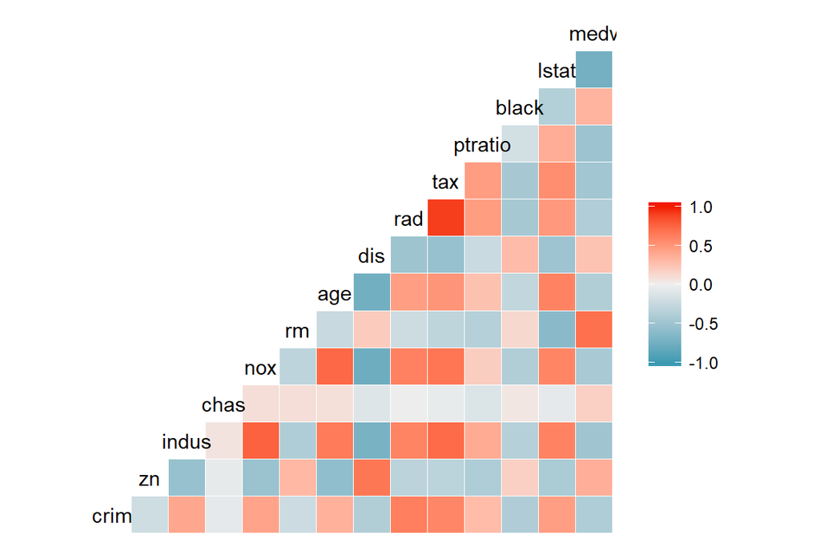

```r
library(GGally)
ggcorr(Boston)
```

There are a fex strong correlations:

- indus/nox:

```r
cor(Boston$indus,Boston$nox)
```

```
## [1] 0.7636514
```

- rad/tax:

```r
cor(Boston$rad,Boston$tax)
```

```
## [1] 0.9102282
```

- indus/tax:

```r
cor(Boston$indus,Boston$tax)
```

```
## [1] 0.7207602
```

They make sense: industrial areas have more pollution, better communications increase the property’s value. Business facilities seem to pay higher rate of property tax.

## 4.3 Standardizing and splitting the data

### 4.3.1 Stardizing variables

Standardizing variable is achieved by transformation **standVar=(var- mean(var))/standard deviation**. The new variable will have a mean of 0 and variance of 1. It is not bound like a **normalized** variable.

```r
boston_scaled <- as.data.frame(scale(Boston))
summary(boston_scaled)
```

```
##       crim                 zn               indus
##  Min.   :-0.419367   Min.   :-0.48724   Min.   :-1.5563
##  1st Qu.:-0.410563   1st Qu.:-0.48724   1st Qu.:-0.8668
##  Median :-0.390280   Median :-0.48724   Median :-0.2109
##  Mean   : 0.000000   Mean   : 0.00000   Mean   : 0.0000
##  3rd Qu.: 0.007389   3rd Qu.: 0.04872   3rd Qu.: 1.0150
##  Max.   : 9.924110   Max.   : 3.80047   Max.   : 2.4202
##       chas              nox                rm               age
##  Min.   :-0.2723   Min.   :-1.4644   Min.   :-3.8764   Min.   :-2.3331
##  1st Qu.:-0.2723   1st Qu.:-0.9121   1st Qu.:-0.5681   1st Qu.:-0.8366
##  Median :-0.2723   Median :-0.1441   Median :-0.1084   Median : 0.3171
##  Mean   : 0.0000   Mean   : 0.0000   Mean   : 0.0000   Mean   : 0.0000
##  3rd Qu.:-0.2723   3rd Qu.: 0.5981   3rd Qu.: 0.4823   3rd Qu.: 0.9059
##  Max.   : 3.6648   Max.   : 2.7296   Max.   : 3.5515   Max.   : 1.1164
##       dis               rad               tax             ptratio
##  Min.   :-1.2658   Min.   :-0.9819   Min.   :-1.3127   Min.   :-2.7047
##  1st Qu.:-0.8049   1st Qu.:-0.6373   1st Qu.:-0.7668   1st Qu.:-0.4876
##  Median :-0.2790   Median :-0.5225   Median :-0.4642   Median : 0.2746
##  Mean   : 0.0000   Mean   : 0.0000   Mean   : 0.0000   Mean   : 0.0000
##  3rd Qu.: 0.6617   3rd Qu.: 1.6596   3rd Qu.: 1.5294   3rd Qu.: 0.8058
##  Max.   : 3.9566   Max.   : 1.6596   Max.   : 1.7964   Max.   : 1.6372
##      black             lstat              medv
##  Min.   :-3.9033   Min.   :-1.5296   Min.   :-1.9063
##  1st Qu.: 0.2049   1st Qu.:-0.7986   1st Qu.:-0.5989
##  Median : 0.3808   Median :-0.1811   Median :-0.1449
##  Mean   : 0.0000   Mean   : 0.0000   Mean   : 0.0000
##  3rd Qu.: 0.4332   3rd Qu.: 0.6024   3rd Qu.: 0.2683
##  Max.   : 0.4406   Max.   : 3.5453   Max.   : 2.9865
```

### 4.3.2 Creating a categorical variable and splitting the data

Crime rate by quantiles:

```r
quantile(boston_scaled$crim)
```

```
##           0%          25%          50%          75%         100%
## -0.419366929 -0.410563278 -0.390280295  0.007389247  9.924109610
```

We’ll use these quantiles to create a new categorical variable **- crime -** with 4 catogories: low, med low, med high, high. As could be expected, the standardized variable and it’s categorical counterpart a distributed evenly around the mean. We’ll also drop the old continuous variable from the dataset.

Table of **crime**:

```r
bins <- quantile(boston_scaled$crim)
labs = c("low","med_low","med_high","high")
boston_scaled$crime <- cut(boston_scaled$crim, breaks = bins, include.lowest = TRUE,labels=labs)
boston_scaled <- dplyr::select(boston_scaled, -crim)
table(boston_scaled$crime)
```

```
##
##      low  med_low med_high     high
##      127      126      126      127
```

Lastly we’ll split the dataset in 80/20 proportion into **train** and **test** sets.

```r
ind <- sample(nrow(Boston),  size = nrow(Boston) * 0.8)
train <- boston_scaled[ind,]
test <- boston_scaled[-ind,]
```

The training set:

```r
table(train$crime)
```

```
##
##      low  med_low med_high     high
##      100      101      101      102
```

The test set:

```r
table(test$crime)
```

```
##
##      low  med_low med_high     high
##       27       25       25       25
```

As can be seen, **sample** function doesn’t necessarily retain the original distribution of the variable of interest when splitting. If that is the goal, **caret** package in R can be used. But we won’t bother with that this time.

## 4.4 Building the model

Linear Discriminant analysis is a classification (and dimension reduction) method. It finds the (linear) combination of the variables that separate the target variable classes. The target can be binary or multiclass variable. We build a model with crime as outcome and all other variables as explanatory. Then we print it.

```r
lda.fit <- lda(crime ~ ., data = train)
lda.fit
```

```
## Call:
## lda(crime ~ ., data = train)
##
## Prior probabilities of groups:
##       low   med_low  med_high      high
## 0.2475248 0.2500000 0.2500000 0.2524752
##
## Group means:
##                   zn      indus        chas        nox         rm
## low       1.08485002 -0.9272524 -0.07547406 -0.8975591  0.4827602
## med_low  -0.09773749 -0.2895741 -0.03844192 -0.5736931 -0.1367599
## med_high -0.38450487  0.2184678  0.19544522  0.4487319  0.0376376
## high     -0.48724019  1.0149946 -0.04073494  1.0593578 -0.4649383
##                 age        dis        rad        tax     ptratio
## low      -0.8944199  0.8989843 -0.6821213 -0.7365568 -0.46492329
## med_low  -0.3970985  0.3705172 -0.5554602 -0.4807210 -0.08098845
## med_high  0.4626517 -0.4071767 -0.4019522 -0.2792200 -0.29867851
## high      0.8135529 -0.8607923  1.6596029  1.5294129  0.80577843
##                black       lstat        medv
## low       0.37559909 -0.77405344  0.55758787
## med_low   0.32023672 -0.14825622  0.02043967
## med_high  0.05805829  0.02961622  0.10139498
## high     -0.86431115  0.97355706 -0.75934627
##
## Coefficients of linear discriminants:
##                 LD1          LD2         LD3
## zn       0.10552640  0.704068903 -1.02493134
## indus   -0.05003515 -0.197412609  0.28150259
## chas    -0.06536474 -0.011144983  0.05890265
## nox      0.29351668 -0.807022705 -1.26778801
## rm      -0.11629142  0.005122386 -0.11263980
## age      0.28294677 -0.337178705 -0.31234629
## dis     -0.15830819 -0.280890951  0.21244424
## rad      3.18007585  0.984520722 -0.11243912
## tax      0.01117687 -0.074877187  0.63193830
## ptratio  0.14559885  0.041238734 -0.30854177
## black   -0.16500805  0.009191302  0.10349072
## lstat    0.16665161 -0.151036013  0.42170745
## medv     0.14851245 -0.383629709 -0.11245252
##
## Proportion of trace:
##    LD1    LD2    LD3
## 0.9438 0.0418 0.0144
```

Some explanations of the output:

- Prior probabilities show that crime is about as equal to fall into any of the categories, which makes sense because it was created by quantiles.
- The first linear discriminant function LD1 achieves 95% of the separation.

The following plot of the model is ripped off straight from DataCamp exercises. It’s not very clear or informative, but due to time pressures I don’t have the time time to make it better. Sorry.

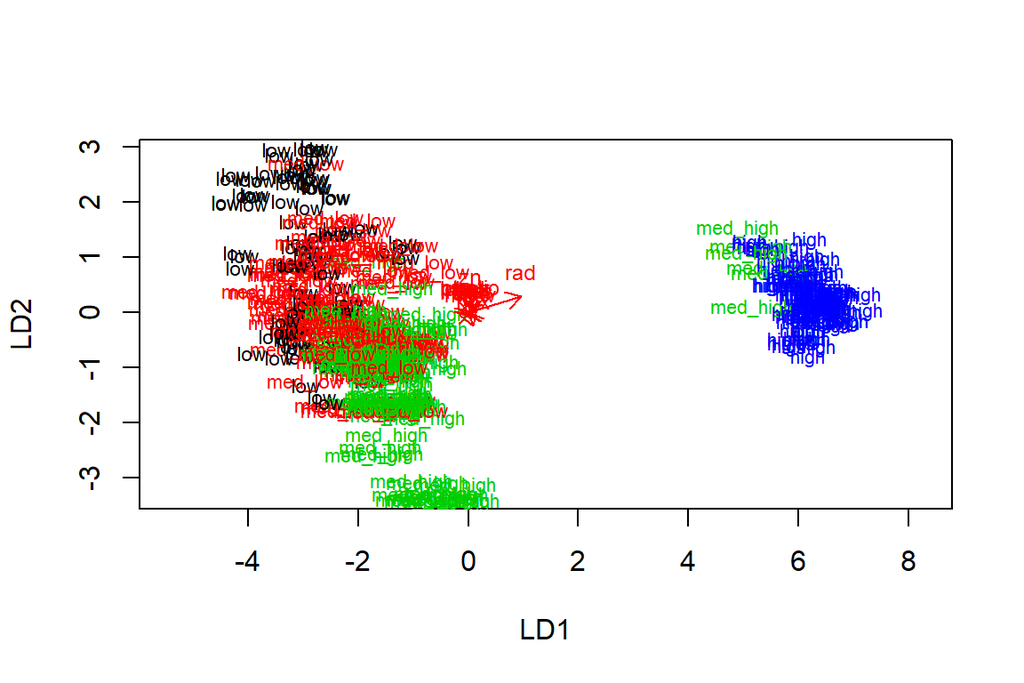

```r
lda.arrows <- function(x, myscale = 1, arrow_heads = 0.1, color = "red", tex = 0.75, choices = c(1,2)){
  heads <- coef(x)
  arrows(x0 = 0, y0 = 0,
         x1 = myscale * heads[,choices[1]],
         y1 = myscale * heads[,choices[2]], col=color, length = arrow_heads)
  text(myscale * heads[,choices], labels = row.names(heads),
       cex = tex, col=color, pos=3)
}
# target classes as numeric
classes <- as.numeric(train$crime)
# plot the lda results
plot(lda.fit, dimen = 2,col=classes,pch=classes)
lda.arrows(lda.fit, myscale = 0.3)
```

## 4.5 Prediction

Part 6 of Analysis: “Save the crime categories from the test set and then remove the categorical crime variable from the test dataset. Then predict the classes with the LDA model on the test data. Cross tabulate the results with the crime categories from the test set.” (Click “Code” to see - well- the code.)

```r
correct_classes = test$crime
test <- dplyr::select(test, -crime)
lda.pred <- predict(lda.fit, newdata = test)
```

Predicted values vs. actual values:

```r
confu = table(correct = correct_classes, predicted = lda.pred$class)
confu
```

```
##           predicted
## correct    low med_low med_high high
##   low       12      12        3    0
##   med_low    4      15        6    0
##   med_high   1       7       17    0
##   high       0       0        1   24
```

Proportion of correct predictions:

```r
sum(diag(confu))/nrow(test)
```

```
## [1] 0.6666667
```

So we have about 70% right. (Notice that proportion varies with each new sampling because I didn’t use the **set.seed** command.) Not so great but better than guessing. One notable thing is that almost none of the predictions were off by more than one class; that’s to say that difference between predicted and actual numerical value of factor variable was almost never greater than one. The code used to calculate this under the **Code** link.

Number of predictions off by more than one

```r
correct = as.numeric(correct_classes)
predicted = as.numeric(lda.pred$class)
sum(abs(correct-predicted)>1)
```

```
## [1] 4
```